# 東吳資管 統計(二) 第十組

台灣AIDS發病統計分析

資二B 09156203 薛威豪 / 資二B 09156218 蔡忠叡 / 資二B 09156232 郭乃瑄 / 資二B 09156245 駱宣妤

2021/12/30

#### < 1 >

#### **報告說明:**

##### 愛滋病一直是國際關注的傳染病防治焦點之一，因為其主要影響具有生產力的年輕族群，感染後目前尚無法治癒，

##### 故其不但危害民眾之生命健康，更耗損社會生產力，甚至影響國家競爭力，為了瞭解我國愛滋病的案例發病情況，

##### 我們做了以下的統計:

#### < 2 >

#### **總人數分析:**

##### 下面數據為95年-110年(11月)每年國人AIDS發病人數統計

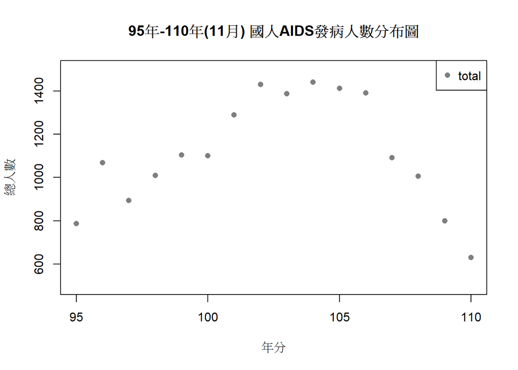

```r
year = c(95,96,97,98,99,100,101,102,103,104,105,106,107,108,109,110)
total = c(787,1069,894,1009,1103,1100,1289,1430,1387,1440,1412,1390,1091,1005,800,631)

plot(x=year,y=total,main="95年-110年(11月) 國人AIDS發病人數分布圖",xlab="年分",ylab="總人數",pch=16,
     col="gray50",ylim=c(500,1500))

legend("topright",pch=16,col="gray50",legend="total")
```

```r
length(total)
```

```
## [1] 16
```

```r
mean(total)
```

```
## [1] 1114.812
```

- 平均數
  $$\bar{x} =\ \frac{\sum x}{n} = \frac{787+1069+894+1009+1103+1100+1289+1430+1387+1440+1412+1390+1091+1005+800,631}{16}=1114.812$$

```r
sd(total)
```

```
## [1] 256.8069
```

```r
library(asbio)
z_test <- one.sample.z(total,                 #放入預檢定資料集
              null.mu = 1000,                 #虛無假設
              xbar = mean(total),             #平均值
              sigma = sd(total),              #標準差
              alternative = "greater",        #檢定方式(右尾)
              conf = 0.95 )                   #信心值
z_test
```

```
##
## One sample z-test
##        z*    P-value
##  1.788309 0.03686309
```

- 假設信心水準為95%
  $$\alpha=0.05$$
  $$Z>Z_{\alpha} = Z_{0.05}=1.645$$

```r
qnorm(0.05,  lower.tail = FALSE)          #假設信心水準為95%
```

```
## [1] 1.644854
```

- rejection region is
  $$Z>1.645$$
- test statistic
  $$z=\frac{\bar{x}-\mu}{\frac{\sigma}{\sqrt n}}=\frac{1114-1000}{\frac{256}{\sqrt{16}}} = 1.788309 \approx 1.79$$
- p-value
  $$p-value = P\left(Z>1.79\right)=1-P\left(Z<1.79\right) = 0.0368$$

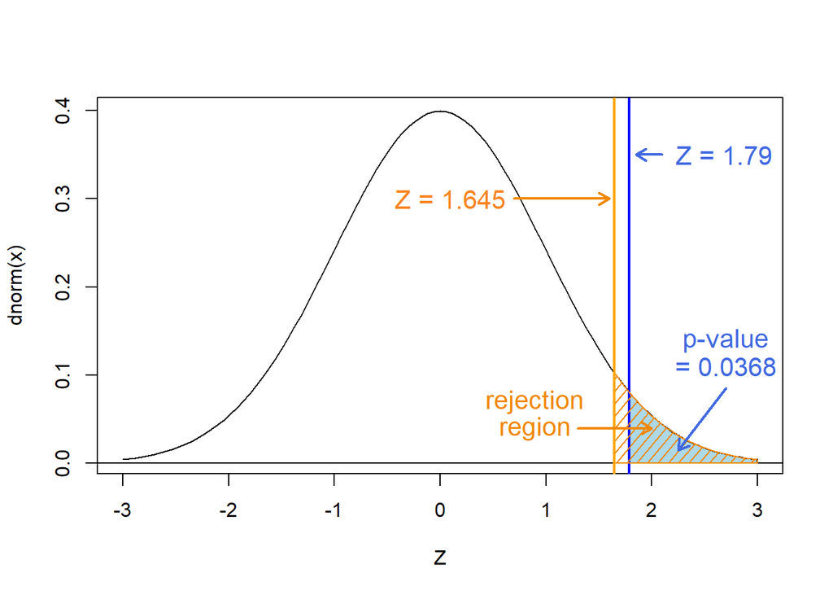

```r
make.shadow <- function(xStart,xEnd,xIncr,func = dnorm, ...)     #編制填上陰影區域
{
  middle = seq(xStart,xEnd,by=xIncr)
  x0 = c(xStart,middle,xEnd)
  y0 = c(0 , func(middle,...),0)
  return(list(x=x0,y=y0))
}

s=make.shadow(z_test$test$`z*`,3,0.05,func = dnorm)              #令s為由0到1.282的區域
curve(dnorm(x),-3,3,xlab="Z")                                    #畫上常態分配
abline(h=0)                                                      #畫上底線
polygon(s$x,s$y,col="lightblue")                                 #畫上p-value的範圍
abline(v=z_test$test$`z*`, lty=1, lwd=2, col="blue")             #畫上檢定統計量的線
s2=make.shadow(1.645,3,0.05,func = dnorm)
polygon(s2$x,s2$y,density = 15,angle = 50, col="#f18800")        #斜線標出拒絕域的範圍
abline(v=1.645, lty=1, lwd=2, col="orange")                      #畫上z=1.645的線

arrows(2.1,0.35,1.85,0.35, angle= 30,code=2,length=0.1,lty=1,lwd=2,col="royalblue")
arrows(0.7,0.3,1.6,0.3, angle= 30,code=2,length=0.1,lty=1,lwd=2,col="#f18800")
text(0.1,0.3, "Z = 1.645",col="#f88421",cex=1.3)
text(2.65,0.35, " Z = 1.79",col="royalblue",cex=1.3)

arrows(2.7,0.085,2.25,0.015, angle= 30,code=2,length=0.1,lty=1,lwd=2,col="royalblue")
text(2.7,0.14, "p-value",col="royalblue",cex=1.3)
text(2.7,0.11, "= 0.0368",col="royalblue",cex=1.3)

arrows(1.3,0.04,2,0.04, angle= 30,code=2,length=0.1,lty=1,lwd=2,col="#f18800")
text(0.9,0.07, "rejection",col="#f18800",cex=1.3)
text(0.9,0.04, "region",col="#f18800",cex=1.3)
```

- 有在拒絕域中，
- **reject H0**，there is enough evidence to infer that the alternative hypothesis is true.
- 因此，有足夠的證據去證明國人AIDS發病普遍會超過1000人。

#### < 3 >

#### **男女分析雙母體 :**

#### ~2030年 消除愛滋第一期計畫

#### 106 年至 110 年 愛滋防治第六期五年計畫

##### 想知道政府做的政策是否有用

##### 所以我們將男性和女性分開來分析

##### 看在101-105年的人數普遍時會否會比106-110年多

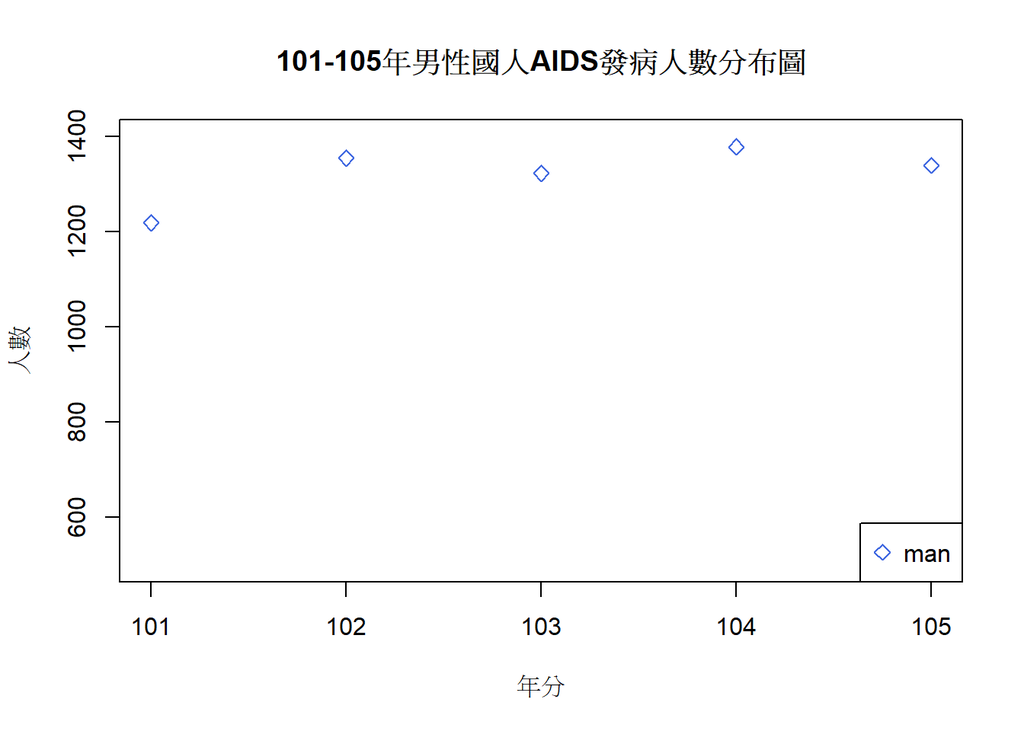

```r
year = c(101,102,103,104,105)
man1 = c(1219,1355,1323,1379,1340)


plot(x=seq(from=101,to=105,by=1),y=man1,main="101-105年男性國人AIDS發病人數分布圖",
     xlab="年分",ylab="人數",pch=5,col="royalblue",ylim=c(500,1400))   #畫出分布圖
legend("bottomright",pch=5,col=c("royalblue"),legend=c("man"))         #加上標示
```

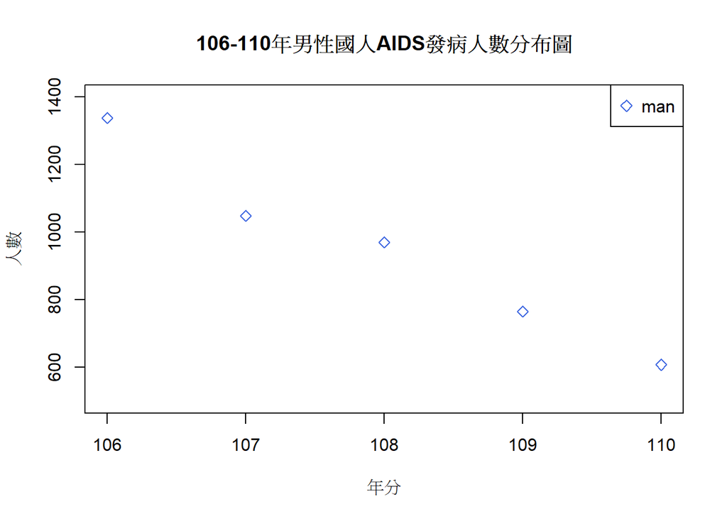

```r
year = c(106,107,108,109,110)
man2 = c(1338,1048,970,765,607)


plot(x=seq(from=106,to=110,by=1),y=man2,main="106-110年男性國人AIDS發病人數分布圖",
     xlab="年分",ylab="人數",pch=5,col="royalblue",ylim=c(500,1400))      #畫出分布圖
legend("topright",pch=5,col=c("royalblue"),legend=c("man"))               #加上標示
```

#### step 1:

##### 利用F檢定判斷變異數是否相同

$$H0: \frac{{\sigma1}^2}{{\sigma2}^2}=1$$
$$H1: \frac{{\sigma1}^2}{{\sigma2}^2} \neq1$$

$${s1}^2=3816.2 , {s2}^2=78081.3 , v1=5-1=4 ,v2=5-1=4$$
- Test statistic
$$F= \frac{{s1}^2}{{s2}^2}= 0.0488$$
- Rejection region :
$$F>F_{\frac{\alpha}{2},v1,v2}=F_{0.025,49,49}\Doteq\ \ F_{0.025,4,4}=9.60453\$$
or
$$F<F_{1-\frac{\alpha}{2},v1,v2}=F_{0.975,4,4}=\frac{1}{F_{0.025,4,4}}\ =\frac{1}{9.60453}=0.1041175$$

```r
year1 = c(101,102,103,104,105)
year2 = c(106,107,108,109,110)
man1 = c(1219,1355,1323,1379,1340)
man2 = c(1338,1048,970,765,607)

mean(man1)
```

```
## [1] 1323.2
```

```r
mean(man2)
```

```
## [1] 945.6
```

```r
var(man1)
```

```
## [1] 3816.2
```

```r
var(man2)
```

```
## [1] 78081.3
```

```r
v1 <- (length(man1)-1)
v2 <- (length(man2)-1)

F <- var(man1)/var(man2)
F
```

```
## [1] 0.0488747
```

```r
var.test(man1,man2,ration = 1,alternative = c("two.sided","less","greater"),
         conf.level = 0.95) #顯示F檢定結果
```

```
##
##  F test to compare two variances
##
## data:  man1 and man2
## F = 0.048875, num df = 4, denom df = 4, p-value = 0.01262
## alternative hypothesis: true ratio of variances is not equal to 1
## 95 percent confidence interval:
##  0.005088713 0.469418503
## sample estimates:
## ratio of variances
##          0.0488747
```

```r
# rejection region is F > 9.6045 or F < 0.1041
print(qf(0.025,df1=v1,df2=v2)) #顯示查表結果
```

```
## [1] 0.1041175
```

```r
print(qf(0.975,df1=v1,df2=v2)) #顯示查表結果
```

```
## [1] 9.60453
```

```r
# 0.048875 < 0.1041
# reject H0 (變異數不相同)
```

##### 經過 F 檢定之後，發現兩邊的母體變異數不相同

#### step 2:

##### 使用變異數不同的獨立雙樣本 t 檢定，也就是將 t.test 函數的 var.equal 參數設定為 FALSE：

$$H0 : \left(\mu_1-\mu_2\right)=0$$
$$H1 : \left(\mu_1-\mu_2\right)\neq0$$
$$\bar{x_1}=1323.2,\bar{x_2}=945.6,{s1}^2=3816.2 ,{s2}^2=78081.3$$
- Degree of freedom
$$v\ =\ \frac{\left(\frac{s_1^2}{n_1}+\frac{s_2^2}{n_2}\right)}{\frac{\left(\frac{s_1}{n_1}\right)^2}{n_1-1}+\frac{\left(\frac{s_2^2}{n_2}\right)^2}{n_2-1}}=268288020/(145633.8+60966894) = 4.39$$
- Rejection region :
$$t<-t_{\frac{\alpha}{2},v}=-2.681809$$
or
$$t>t_{\frac{\alpha}{2},v}=2,681809$$
-Test statistic :
$$t=\frac{\left(\bar{x_1}-\bar{x_2}\right)-\left(\mu_1-\mu_2\right)}{\sqrt{\frac{s_{1^2}}{n_1}+\frac{s_2^2}{n_2}}}=2.9504$$

- 2.9504 > 2,6818
- **reject Ho**
- 有足夠證據說明男性在101-105年平均人數大於106-110年

```r
t.test(man1,man2, var.equal = FALSE)#顯示查表結果
```

```
##
##  Welch Two Sample t-test
##
## data:  man1 and man2
## t = 2.9504, df = 4.3901, p-value = 0.03739
## alternative hypothesis: true difference in means is not equal to 0
## 95 percent confidence interval:
##   34.3756 720.8244
## sample estimates:
## mean of x mean of y
##    1323.2     945.6
```

```r
a=(var(man1)/length(man1)+var(man2)/length(man2))^2
a
```

```
## [1] 268288020
```

```r
b=(var(man1)/length(man1))^2/(length(man1)-1)+(var(man2)/length(man2))^2/(length(man2)-1)

v=a/b
v #自由度
```

```
## [1] 4.390066
```

```r
# rejection region is t > 2.6818 or F < -2.6818
print(qt(0.025,df=v))
```

```
## [1] -2.681809
```

```r
print(qt(0.975,df=v))
```

```
## [1] 2.681809
```

```r
# 2.9504 > 2.6818 ,reject H0
```

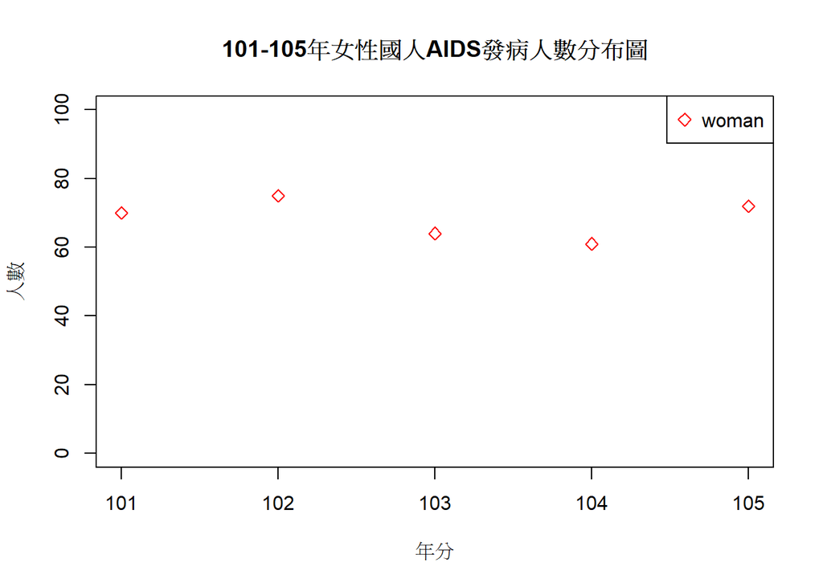

```r
year = c(101,102,103,104,105)
woman1 = c(70,75,64,61,72)

plot(x=seq(from=101,to=105,by=1),y=woman1,main="101-105年女性國人AIDS發病人數分布圖",
     xlab="年分",ylab="人數",pch=5,col="red",ylim=c(0,100))      #畫出分布圖
legend("topright",pch=5,col=c("red"),legend=c("woman"))          #加上標示
```

[figure not shown]

```r
year = c(106,107,108,109,110)
woman2 = c(52,43,35,35,24)

plot(x=seq(from=101,to=105,by=1),y=woman2,main="106-110年女性國人AIDS發病人數分布圖",
     xlab="年分",ylab="人數",pch=5,col="red",ylim=c(0,100))      #畫出分布圖
legend("topright",pch=5,col=c("red"),legend=c("woman"))          #加上標示
```

#### step 1:

##### 利用F檢定判斷變異數是否相同

```r
woman1 = c(70,75,64,61,72)
woman2 = c(52,43,35,35,24)

mean(woman1)
```

```
## [1] 68.4
```

```r
mean(woman2)
```

```
## [1] 37.8
```

```r
var(woman1)
```

```
## [1] 33.3
```

```r
var(woman2)
```

```
## [1] 108.7
```

```r
v1 <- (length(woman1)-1)
v2 <- (length(woman2)-1)

F <- var(woman1)/var(woman2)
F
```

```
## [1] 0.3063477
```

```r
var.test(woman1,woman2,ration = 1,alternative = c("two.sided","less","greater"),
         conf.level = 0.95) #顯示F檢定結果
```

```
##
##  F test to compare two variances
##
## data:  woman1 and woman2
## F = 0.30635, num df = 4, denom df = 4, p-value = 0.2784
## alternative hypothesis: true ratio of variances is not equal to 1
## 95 percent confidence interval:
##  0.03189617 2.94232608
## sample estimates:
## ratio of variances
##          0.3063477
```

```r
# rejection region is F > 9.6045 or F < 0.1041
print(qf(0.025,df1=v1,df2=v2)) #顯示查表結果
```

```
## [1] 0.1041175
```

```r
print(qf(0.975,df1=v1,df2=v2)) #顯示查表結果
```

```
## [1] 9.60453
```

```r
#  0.1041 < 0.3063 < 9.6045
# not reject H0 (變異數相同)
```

##### 經過 F 檢定之後，發現兩邊的母體變異數相同

#### step 2:

##### 所以使用變異數相同的獨立雙樣本 t 檢定，也就是將 t.test 函數的 var.equal 參數設定為 TRUE：

$$H0 : \left(\mu_1-\mu_2\right)=0$$
$$H1 : \left(\mu_1-\mu_2\right)>0$$
$$\bar{x_1}=68.4,\bar{x_2}=37.8,{s1}^2=33.3 ,{s2}^2=108.7$$

- Pooled variance estimator:
  $$S_{p=}^2\frac{\left(n_1-1\right)\times S_1^2+\left(n_2-1\right)\times S_2^2}{n_1+n_2-2}=71$$
- Degree of freedom :
  $$v=n_1+n_2-2=8$$
- Rejection region :
  $$t>t_{\alpha,v}=1.859548$$

-Test statistic :
$$t=\frac{\left(\bar{x_1}-\bar{x_2}\right)-\left(\mu_1-\mu_2\right)}{\sqrt{s_P^2\times\left(\frac{1}{n_1}+\frac{1}{n_2}\right)}}=5.742$$

- 5.742 > 1.8595
- **reject Ho**
- 有足夠證據說明女性在101-105年平均人數大於106-110年

```r
t.test(woman1,woman2, var.equal = TRUE)#顯示查表結果
```

```
##
##  Two Sample t-test
##
## data:  woman1 and woman2
## t = 5.742, df = 8, p-value = 0.000433
## alternative hypothesis: true difference in means is not equal to 0
## 95 percent confidence interval:
##  18.31092 42.88908
## sample estimates:
## mean of x mean of y
##      68.4      37.8
```

```r
v = length(woman1)+length(woman1)-2
v
```

```
## [1] 8
```

```r
a = (length(woman1)-1)*var(woman1)+(length(woman2)-1)*var(woman2)
a
```

```
## [1] 568
```

```r
b = length(woman1)+length(woman1)-2
b
```

```
## [1] 8
```

```r
Sp2 = a/b
Sp2
```

```
## [1] 71
```

```r
# rejection region is t > 1.8595
print(qt(0.95,df=v))
```

```
## [1] 1.859548
```

```r
# 5.742> 1.8595 ,reject H0
```